# Assignment 2: Some solutions

Michael Friendly

2023-02-09

## Exercise 2.3

```r
data(UCBAdmissions)
UCB <- UCBAdmissions   # save typing
ftable(UCB)
```

```
##                 Dept   A   B   C   D   E   F
## Admit    Gender
## Admitted Male        512 353 120 138  53  22
##          Female       89  17 202 131  94  24
## Rejected Male        313 207 205 279 138 351
##          Female       19   8 391 244 299 317
```

1. total number of cases

```r
sum(UCB)
```

```
## [1] 4526
```

2. total applicants for each dept

```r
margin.table(UCB, 3)
```

```
## Dept
##   A   B   C   D   E   F
## 933 585 918 792 584 714
```

```r
apply(UCBAdmissions, 3, sum)
```

```
##   A   B   C   D   E   F
## 933 585 918 792 584 714
```

3. proportion admitted for each dept

```r
tab1 <- margin.table(UCB , c(1,3))
tab1
```

```
##           Dept
## Admit        A   B   C   D   E   F
##   Admitted 601 370 322 269 147  46
##   Rejected 332 215 596 523 437 668
```

```r
tab1[1,] / margin.table(UCB, 3)
```

```
## Dept
##          A          B          C          D          E          F
## 0.64415863 0.63247863 0.35076253 0.33964646 0.25171233 0.06442577
```

or, using prop.table

```r
prop.table(margin.table(UCB, c(1, 3)),2)
```

```
##           Dept
## Admit               A          B          C          D          E          F
##   Admitted 0.64415863 0.63247863 0.35076253 0.33964646 0.25171233 0.06442577
##   Rejected 0.35584137 0.36752137 0.64923747 0.66035354 0.74828767 0.93557423
```

4. proportion in each cell admitted There are different ways to do this. Perhaps easiest is to extract the subtables of admitted vs. rejected and divide

```r
admit <- UCB[1,,]
reject <- UCB[2,,]

admit / (admit+reject)
```

```
##         Dept
## Gender            A          B          C          D          E          F
##   Male   0.62060606 0.63035714 0.36923077 0.33093525 0.27748691 0.05898123
##   Female 0.82407407 0.68000000 0.34064081 0.34933333 0.23918575 0.07038123
```

## Exercise 3.1: Arbuthnot data

load the data

```r
data(Arbuthnot, package="HistData")
```

1. Plot `Ratio` vs. `Year` This uses old-school base R features: `plot()`, `abline()`, `loess.smooth()` and `lines()`

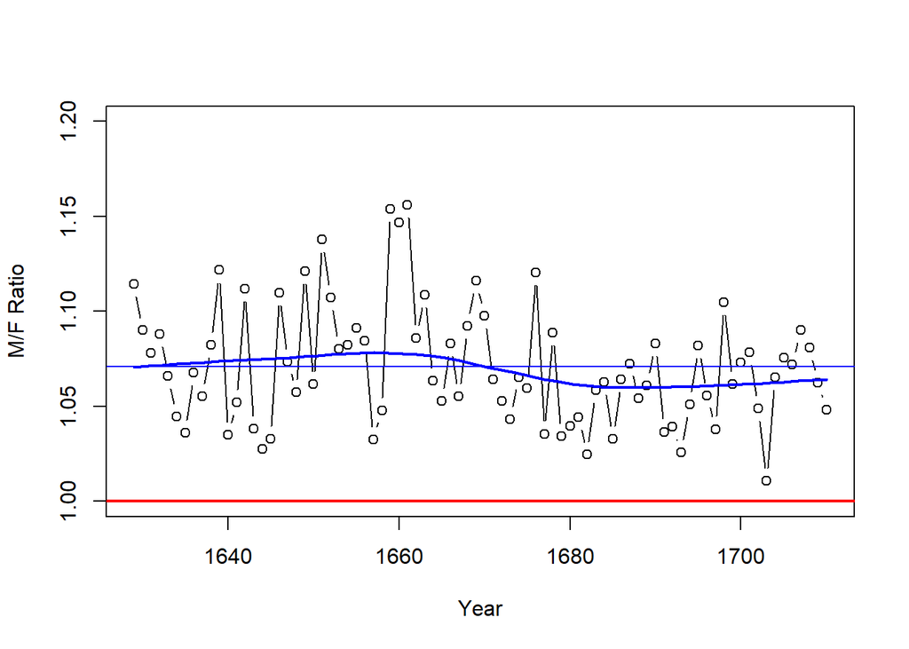

```r
plot(Ratio ~ Year,
     data=Arbuthnot,
     type="b",
     ylim=c(1.0,1.2),
     ylab="M/F Ratio")
abline(h=1.0,col="red",lwd=2)
abline(h=mean(Arbuthnot$Ratio), col="blue")
Arb.sm <- loess.smooth(Arbuthnot$Year, Arbuthnot$Ratio)
lines(Arb.sm, col="blue", lwd=2)
```

using with() evaluates in the environment of a data frame, saves typing Arbuthnot$…

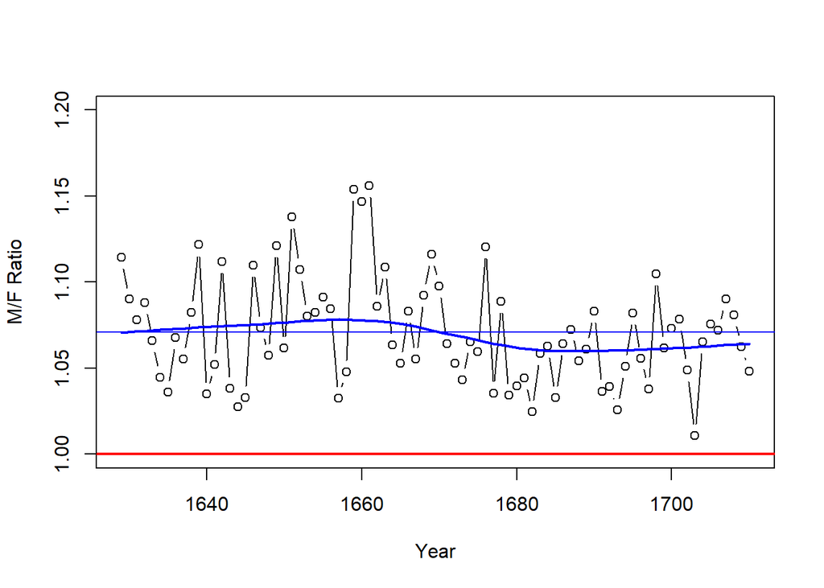

```r
with(Arbuthnot, {
    plot(Ratio ~ Year,
         type="b",
         ylim=c(1.0,1.2),
         ylab="M/F Ratio")
    abline(h=1.0, col="red", lwd=2)
    abline(h=mean(Ratio), col="blue")
    lines(loess.smooth(Year, Ratio), col="blue", lwd=2)
    })
```

### (b) Total christenings

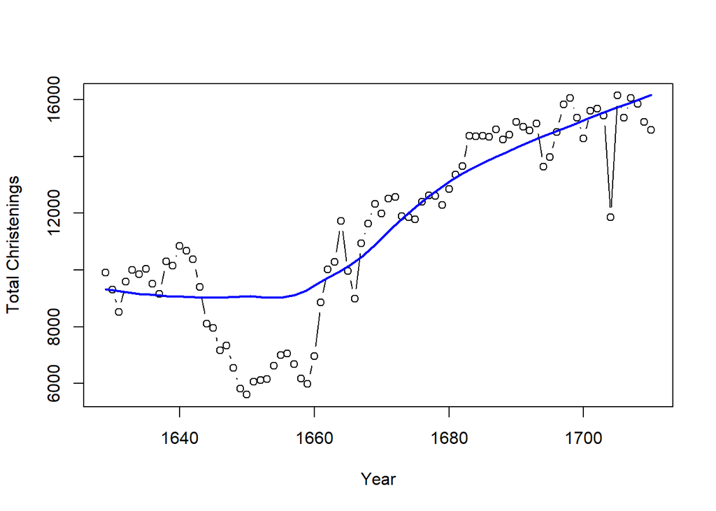

```r
with(Arbuthnot, {
    Total <- Males + Females
    plot(Total ~ Year,
         type="b",
         ylab="Total Christenings")
    Arb.sm <- loess.smooth(Year, Total)
    lines(Arb.sm, col="blue", lwd=2)
    })
```

### Part (a) using `ggplot`

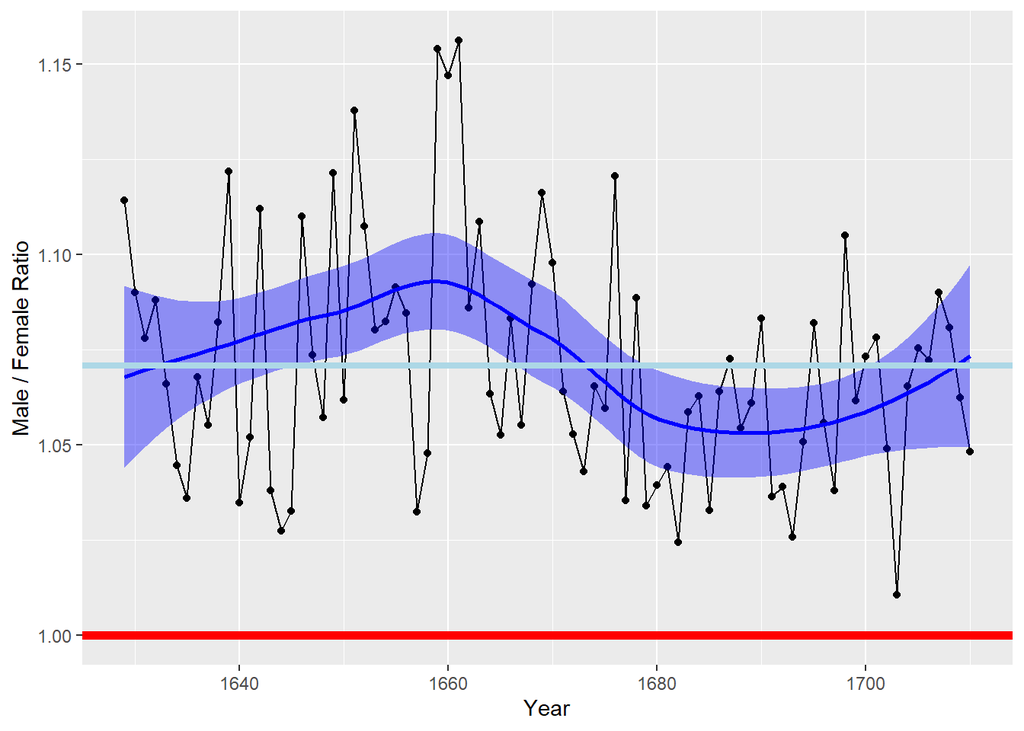

```r
library(ggplot2)
Arbuthnot |>
  ggplot(aes(x=Year, y=Ratio)) +
    geom_point() +
    geom_line() +
    geom_smooth(method = "loess", formula = y~x, color = "blue", fill="blue") +
    geom_hline(yintercept = 1, color = "red", size = 2) +
    geom_hline(aes(yintercept = mean(Ratio)), color = "lightblue", size = 1.5) +
    ylab("Male / Female Ratio")
```

## Exercise 3.3: WomenQueue

1. Barplots

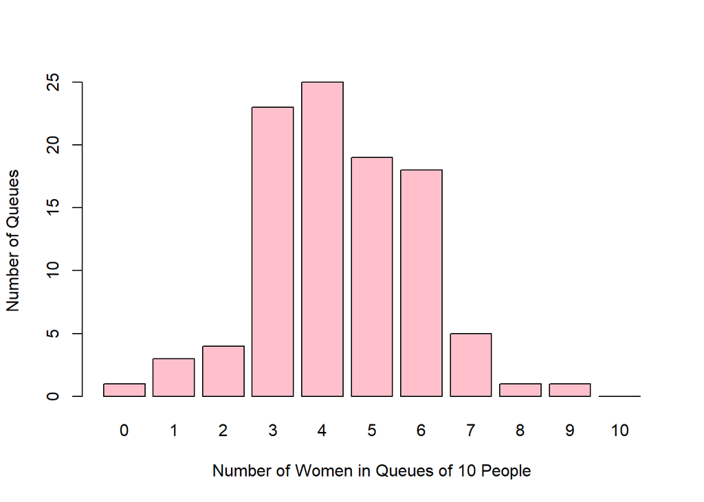

```r
data(WomenQueue, package = "vcd")
barplot(WomenQueue, xlab="Number of Women in Queues of 10 People",
    ylab="Number of Queues", col="pink")
```

2. Goodness of fit

```r
WQfit1 <- goodfit(WomenQueue, type="binomial", par=list(size=10))
unlist(WQfit1$par)
```

```
##   prob   size
##  0.435 10.000
```

```r
summary(WQfit1)
```

```
##
##   Goodness-of-fit test for binomial distribution
##
##                       X^2 df  P(> X^2)
## Likelihood Ratio 8.650999  8 0.3725869
```

3. Plot

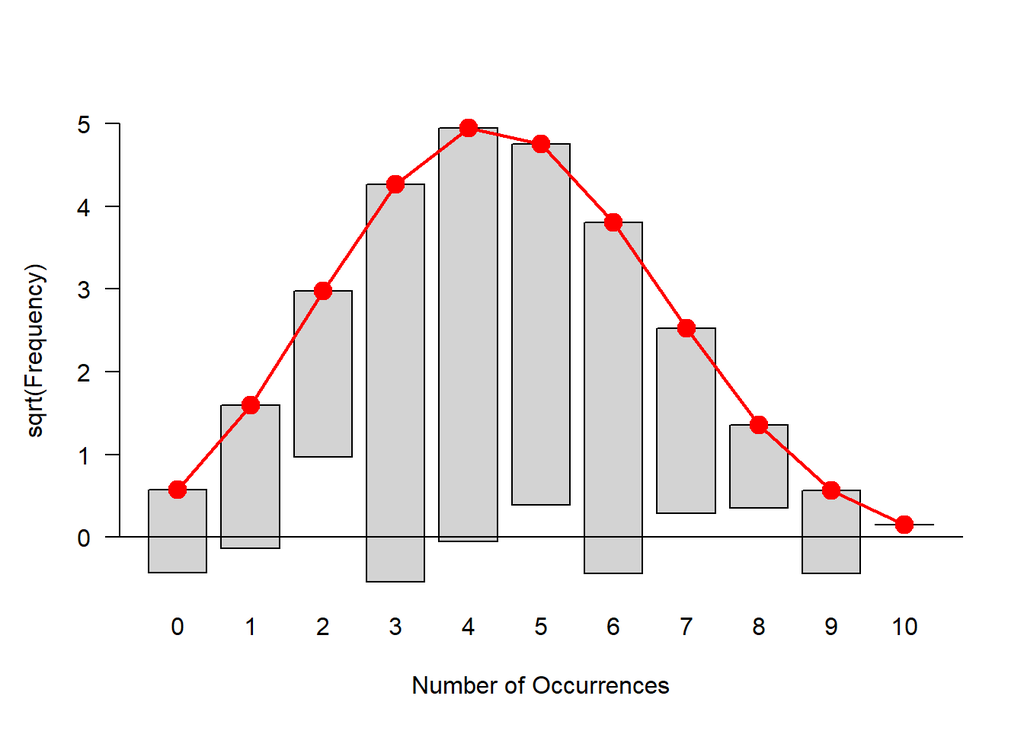

```r
plot(WQfit1, type="hanging")
```

## Exercise 3.4: Saxony data

```r
data(Saxony, package = "vcd")
```

1. To test goodness of fit of the binomial with an estimated value, $\hat{p}$, only specify max. count, `size` as a parameter

```r
Saxfit <- goodfit(Saxony, type="binomial", par=list(size=12))
unlist(Saxfit$par)
```

```
##      prob      size
##  0.519215 12.000000
```

The summary() method gives the likelihood ratio test for goodness of fit. $X^2 / df = 97 / 11 = 8.81$ is large (should be $\approx 1$ for a good fitting model).

```r
summary(Saxfit)
```

```
##
##   Goodness-of-fit test for binomial distribution
##
##                      X^2 df     P(> X^2)
## Likelihood Ratio 97.0065 11 6.978187e-16
```

Plot with a hanging rootogram

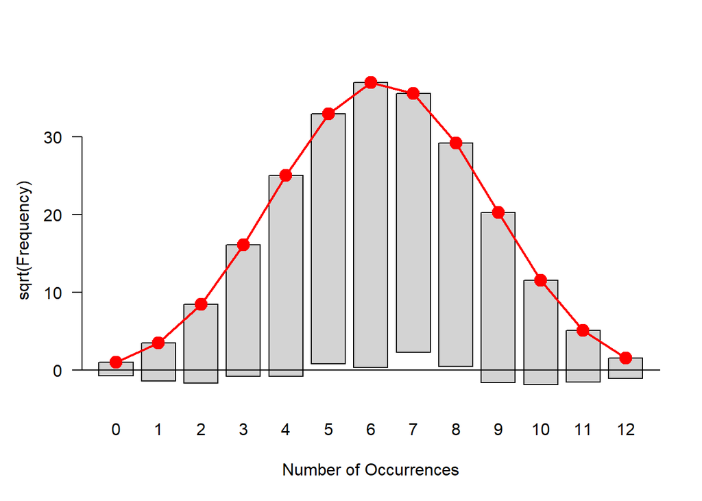

```r
plot(Saxfit)
```

2. To test the model $Bin(n=12, p = 1/2)$, you need to also specify the `prob` parameter

```r
Saxfit1 <- goodfit(Saxony, type="binomial", par=list(size=12, prob=0.5))
unlist(Saxfit1$par)
```

```
## prob size
##  0.5 12.0
```

Again, get the GOF test from `summary()` To test for additional lack of fit for the model $Bin(n=12, p = 1/2)$ compared to the model $Bin(n=12, p = \hat{p})$, you have to subtract manually: $\Delta \chi^2 = 205 - 97 = 108$ on 1 df.

```r
summary(Saxfit1)
```

```
##
##   Goodness-of-fit test for binomial distribution
##
##                       X^2 df     P(> X^2)
## Pearson          249.1954 12 2.013281e-46
## Likelihood Ratio 205.4060 12 2.493625e-37
```

Plot the constrained model with a hanging rootogram

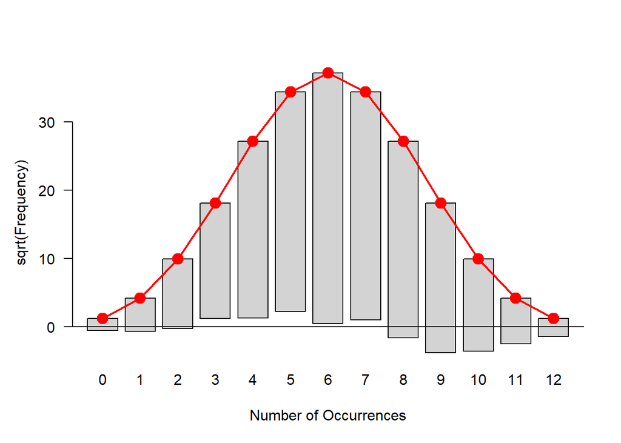

```r
plot(Saxfit1)
```